# **EDA**

# **Classification Problem**

For our classification problem, we are going to use the supervised learning models to predict whether or not a property borders the Charles River.

```python
#first we must look at the target variable proportions
pd.crosstab(df['CHAS'],df['CHAS'], normalize='all')*100
```

| CHAS | 0.0 | 1.0 |
| --- | --- | --- |
| 0.0 | 93.083004 | 0.000000 |
| 1.0 | 0.000000 | 6.916996 |

It looks like our target variable is unbalanced, so we should not trust accuracy scores - instead, we'll look at F1 scores to determine how well our model is doing.

## Logistic Regression

There aren't any categorical variables in this data set other than the dummy for CHAS, so there's no need to use the get_dummies tool from pandas.

```python
df = pd.read_csv("boston_clean.csv")
```

```python
df.head()
```

|  | CRIM | ZN | INDUS | CHAS | NOX | RM | AGE | DIS | RAD | TAX | PTRATIO | B | LSTAT | price |
| --- | --- | --- | --- | --- | --- | --- | --- | --- | --- | --- | --- | --- | --- | --- |
| 0 | 0.00632 | 18.0 | 2.31 | 0.0 | 0.538 | 6.575 | 65.2 | 4.0900 | 1.0 | 296.0 | 15.3 | 396.90 | 4.98 | 24.0 |
| 1 | 0.02731 | 0.0 | 7.07 | 0.0 | 0.469 | 6.421 | 78.9 | 4.9671 | 2.0 | 242.0 | 17.8 | 396.90 | 9.14 | 21.6 |
| 2 | 0.02729 | 0.0 | 7.07 | 0.0 | 0.469 | 7.185 | 61.1 | 4.9671 | 2.0 | 242.0 | 17.8 | 392.83 | 4.03 | 34.7 |
| 3 | 0.03237 | 0.0 | 2.18 | 0.0 | 0.458 | 6.998 | 45.8 | 6.0622 | 3.0 | 222.0 | 18.7 | 394.63 | 2.94 | 33.4 |
| 4 | 0.06905 | 0.0 | 2.18 | 0.0 | 0.458 | 7.147 | 54.2 | 6.0622 | 3.0 | 222.0 | 18.7 | 396.90 | 5.33 | 36.2 |

```python
#SET UP TESTING AND TRAINING DATA
```

```python
y = df['CHAS']
X = df.drop('CHAS', axis=1)
```

```python
X_train, X_test, y_train, y_test = train_test_split(X, y, test_size=0.3, random_state=rand_state)
```

```python
logistic = LogisticRegression()
logistic.fit(X_train, y_train)
```

```
LogisticRegression()
```

```python
#plotting histogram
```

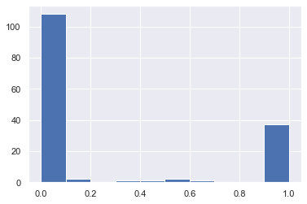

```python
plt.hist(y_hat_probs)
plt.show()
```

```python
y_hat_30 = np.where(y_hat_probs>0.30,1,0)
y_hat_60 = np.where(y_hat_probs>0.60,1,0)
y_hat_80 = np.where(y_hat_probs>0.80,1,0)
```

```python
df_predictions = pd.DataFrame({'y_test':y_test, 'y_hat_probs':y_hat_probs, 'y_hat_30':y_hat_30, 'y_hat_60':y_hat_60, 'y_hat_80':y_hat_80,})
df_predictions.head()
```

|  | y_test | y_hat_probs | y_hat_30 | y_hat_60 | y_hat_80 |
| --- | --- | --- | --- | --- | --- |
| 483 | 0.0 | 4.568298e-11 | 0 | 0 | 0 |
| 426 | 0.0 | 9.829319e-02 | 0 | 0 | 0 |
| 22 | 0.0 | 2.947781e-10 | 0 | 0 | 0 |
| 268 | 0.0 | 5.114312e-09 | 0 | 0 | 0 |
| 371 | 0.0 | 1.000000e+00 | 1 | 1 | 1 |

```python
#confusion matrix
```

```python
from sklearn.metrics import confusion_matrix
from sklearn.metrics import accuracy_score, recall_score, precision_score, f1_score



def my_logistic_report(X_train, y_train, X_test,y_test, threshold=0.15): # you could make it even more general!
    logistic= LogisticRegression()
    logistic.fit(X_train, y_train)
    probs = logistic.predict_proba(X_test)[:,1]
    y_hat = np.where(probs>=threshold,1,0)

    cm = confusion_matrix(y_test, y_hat)
    accuracy = round(accuracy_score(y_test,y_hat) ,2)
    precision = round(precision_score(y_test,y_hat),2)
    recall = round(recall_score(y_test,y_hat),2)
    f1score = round(f1_score(y_test,y_hat),2)
    cm_labled = pd.DataFrame(cm, index=['Actual : negative ','Actual : positive'], columns=['Predict : negative','Predict :positive '])

    print("-----------------------------------------")
    print('Accuracy  = {}'.format(accuracy))
    print('Precision = {}'.format(precision))
    print('Recall    = {}'.format(recall))
    print('f1_score  = {}'.format(f1score))
    print("-----------------------------------------")
    return cm_labled
```

```python
#logistic report
```

```python
my_logistic_report(X_train, y_train, X_test,y_test, threshold=0.15)
```

```
-----------------------------------------
Accuracy  = 0.84
Precision = 0.11
Recall    = 0.22
f1_score  = 0.14
-----------------------------------------
```

|  | Predict : negative | Predict :positive |
| --- | --- | --- |
| Actual : negative | 126 | 17 |
| Actual : positive | 7 | 2 |

```python
my_logistic_report(X_train, y_train, X_test,y_test, threshold=0.10)
```

```
-----------------------------------------
Accuracy  = 0.76
Precision = 0.09
Recall    = 0.33
f1_score  = 0.14
-----------------------------------------
```

|  | Predict : negative | Predict :positive |
| --- | --- | --- |
| Actual : negative | 112 | 31 |
| Actual : positive | 6 | 3 |

Changing the threshold decreases accuracy from 84% to 76%. The amount of false positives went up to 31 and the number of false negatives went down to 6. The F1 score did not improve. Lastly, let's take a look at the ROC AUC score to see how much better we're doing than no-skill prediction.

```
No Skill: ROC AUC=0.500
Logistic: ROC AUC=0.765
```

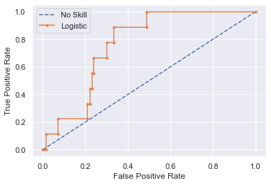

```python
# generate a no skill (ns) prediction and logistic regression (lr) predictions.
ns_probs = [0.5 for i in range(len(y_test))]
lr_probs = logistic.predict_proba(X_test)[:,1]
# calculating scores for no skill and logistic regression
ns_auc = roc_auc_score(y_test, ns_probs)
lr_auc = roc_auc_score(y_test, lr_probs)
print('No Skill: ROC AUC=%.3f' % (ns_auc))
print('Logistic: ROC AUC=%.3f' % (lr_auc))

# calculate roc curves
ns_fpr, ns_tpr, _ = roc_curve(y_test, ns_probs)
lr_fpr, lr_tpr, _ = roc_curve(y_test, lr_probs)
# plot the roc curve for the model
plt.plot(ns_fpr, ns_tpr, linestyle='--', label='No Skill')
plt.plot(lr_fpr, lr_tpr, marker='.', label='Logistic')
# axis labels
plt.xlabel('False Positive Rate')
plt.ylabel('True Positive Rate')
# show the legend
plt.legend()
# show the plot
plt.show()
```

## KNN Classification

```python
df = pd.read_csv("boston_clean.csv")
```

```python
df.head()
```

|  | CRIM | ZN | INDUS | CHAS | NOX | RM | AGE | DIS | RAD | TAX | PTRATIO | B | LSTAT | price |
| --- | --- | --- | --- | --- | --- | --- | --- | --- | --- | --- | --- | --- | --- | --- |
| 0 | 0.00632 | 18.0 | 2.31 | 0.0 | 0.538 | 6.575 | 65.2 | 4.0900 | 1.0 | 296.0 | 15.3 | 396.90 | 4.98 | 24.0 |
| 1 | 0.02731 | 0.0 | 7.07 | 0.0 | 0.469 | 6.421 | 78.9 | 4.9671 | 2.0 | 242.0 | 17.8 | 396.90 | 9.14 | 21.6 |
| 2 | 0.02729 | 0.0 | 7.07 | 0.0 | 0.469 | 7.185 | 61.1 | 4.9671 | 2.0 | 242.0 | 17.8 | 392.83 | 4.03 | 34.7 |
| 3 | 0.03237 | 0.0 | 2.18 | 0.0 | 0.458 | 6.998 | 45.8 | 6.0622 | 3.0 | 222.0 | 18.7 | 394.63 | 2.94 | 33.4 |
| 4 | 0.06905 | 0.0 | 2.18 | 0.0 | 0.458 | 7.147 | 54.2 | 6.0622 | 3.0 | 222.0 | 18.7 | 396.90 | 5.33 | 36.2 |

```python
from sklearn.preprocessing import StandardScaler
scaler=StandardScaler()
df_sc= scaler.fit_transform(df)
```

```python
df_sc = pd.DataFrame(df_sc, columns=df.columns)
df_sc.head()
```

|  | CRIM | ZN | INDUS | CHAS | NOX | RM | AGE | DIS | RAD | TAX | PTRATIO | B | LSTAT | price |
| --- | --- | --- | --- | --- | --- | --- | --- | --- | --- | --- | --- | --- | --- | --- |
| 0 | -0.419782 | 0.284830 | -1.287909 | -0.272599 | -0.144217 | 0.413672 | -0.120013 | 0.140214 | -0.982843 | -0.666608 | -1.459000 | 0.441052 | -1.075562 | 0.159686 |
| 1 | -0.417339 | -0.487722 | -0.593381 | -0.272599 | -0.740262 | 0.194274 | 0.367166 | 0.557160 | -0.867883 | -0.987329 | -0.303094 | 0.441052 | -0.492439 | -0.101524 |
| 2 | -0.417342 | -0.487722 | -0.593381 | -0.272599 | -0.740262 | 1.282714 | -0.265812 | 0.557160 | -0.867883 | -0.987329 | -0.303094 | 0.396427 | -1.208727 | 1.324247 |
| 3 | -0.416750 | -0.487722 | -1.306878 | -0.272599 | -0.835284 | 1.016303 | -0.809889 | 1.077737 | -0.752922 | -1.106115 | 0.113032 | 0.416163 | -1.361517 | 1.182758 |
| 4 | -0.412482 | -0.487722 | -1.306878 | -0.272599 | -0.835284 | 1.228577 | -0.511180 | 1.077737 | -0.752922 | -1.106115 | 0.113032 | 0.441052 | -1.026501 | 1.487503 |

```python
df_sc['CHAS']=df['CHAS']
df_sc.head(3)
```

|  | CRIM | ZN | INDUS | CHAS | NOX | RM | AGE | DIS | RAD | TAX | PTRATIO | B | LSTAT | price |
| --- | --- | --- | --- | --- | --- | --- | --- | --- | --- | --- | --- | --- | --- | --- |
| 0 | -0.419782 | 0.284830 | -1.287909 | 0.0 | -0.144217 | 0.413672 | -0.120013 | 0.140214 | -0.982843 | -0.666608 | -1.459000 | 0.441052 | -1.075562 | 0.159686 |
| 1 | -0.417339 | -0.487722 | -0.593381 | 0.0 | -0.740262 | 0.194274 | 0.367166 | 0.557160 | -0.867883 | -0.987329 | -0.303094 | 0.441052 | -0.492439 | -0.101524 |
| 2 | -0.417342 | -0.487722 | -0.593381 | 0.0 | -0.740262 | 1.282714 | -0.265812 | 0.557160 | -0.867883 | -0.987329 | -0.303094 | 0.396427 | -1.208727 | 1.324247 |

```python
y = df_sc['CHAS']
X = df_sc.drop('CHAS', axis=1) # becareful inplace= False

from sklearn.model_selection import train_test_split
X_train, X_test, y_train, y_test = train_test_split(X, y, test_size=0.2, random_state=rand_state)
```

```python
from sklearn.neighbors import KNeighborsClassifier
```

```python
KNN_classifier = KNeighborsClassifier(n_neighbors=5)
KNN_classifier.fit(X_train, y_train)
```

```
KNeighborsClassifier()
```

```python
y_hat      = KNN_classifier.predict(X_test)
y_hat_probs = KNN_classifier.predict_proba(X_test)[:,1]
```

```python
np.round(KNN_classifier.predict_proba(X_test),3)[:5]
```

```
array([[1. , 0. ],
       [1. , 0. ],
       [1. , 0. ],
       [0.8, 0.2],
       [0.4, 0.6]])
```

```python
np.max(y_hat_probs)
```

```
0.6
```

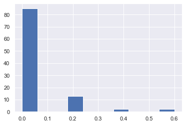

```python
plt.hist(y_hat_probs)
plt.show()
```

```python
y_hat_30 = np.where(y_hat_probs>0.1,1,0)
y_hat_70 = np.where(y_hat_probs>0.3,1,0)
```

```python
df_predictions = pd.DataFrame({'y_test':y_test, 'y_hat_probs':y_hat_probs,
                               'y_hat_30':y_hat_30, 'y_hat_70':y_hat_70})
df_predictions.head()
```

|  | y_test | y_hat_probs | y_hat_30 | y_hat_70 |
| --- | --- | --- | --- | --- |
| 483 | 0.0 | 0.0 | 0 | 0 |
| 426 | 0.0 | 0.0 | 0 | 0 |
| 22 | 0.0 | 0.0 | 0 | 0 |
| 268 | 0.0 | 0.2 | 1 | 0 |
| 371 | 0.0 | 0.6 | 1 | 1 |

```python
from sklearn.metrics import accuracy_score, recall_score, precision_score, f1_score
from sklearn.metrics import confusion_matrix, classification_report, roc_curve, roc_auc_score
```

```python
print(confusion_matrix(y_test, y_hat))
```

```
[[98  1]
 [ 2  1]]
```

```python
print(classification_report(y_test, y_hat))
```

```
              precision    recall  f1-score   support

         0.0       0.98      0.99      0.98        99
         1.0       0.50      0.33      0.40         3

    accuracy                           0.97       102
   macro avg       0.74      0.66      0.69       102
weighted avg       0.97      0.97      0.97       102
```

```python
from sklearn.metrics import confusion_matrix
from sklearn.metrics import accuracy_score, recall_score, precision_score, f1_score



def my_KNN_report(X_train, y_train, X_test,y_test, K=5, threshold=0.5):
    knn= KNeighborsClassifier(n_neighbors=K)
    knn.fit(X_train, y_train)
    probs = knn.predict_proba(X_test)[:,1]
    y_hat = np.where(probs>=threshold,1,0)

    cm = confusion_matrix(y_test, y_hat)
    accuracy = round(accuracy_score(y_test,y_hat) ,4)
    error_rate = round(1-accuracy,4)
    precision = round(precision_score(y_test,y_hat),2)
    recall = round(recall_score(y_test,y_hat),2)
    f1score = round(f1_score(y_test,y_hat),2)
    cm_labled = pd.DataFrame(cm, index=['Actual : negative ','Actual : positive'], columns=['Predict : negative','Predict :positive '])

    print("-----------------------------------------")
    print('Accuracy  = {}'.format(accuracy))
    print('Error_rate  = {}'.format(error_rate))
    print('Precision = {}'.format(precision))
    print('Recall    = {}'.format(recall))
    print('f1_score  = {}'.format(f1score))
    print("-----------------------------------------")
    return cm_labled
```

```python
my_KNN_report(X_train, y_train, X_test,y_test, K=5, threshold=0.5)
```

```
-----------------------------------------
Accuracy  = 0.9706
Error_rate  = 0.0294
Precision = 0.5
Recall    = 0.33
f1_score  = 0.4
-----------------------------------------
```

|  | Predict : negative | Predict :positive |
| --- | --- | --- |
| Actual : negative | 98 | 1 |
| Actual : positive | 2 | 1 |

```python
X_train.shape
```

```
(404, 13)
```

```
No Skill: ROC AUC=0.500
KNN: ROC AUC=0.941
```

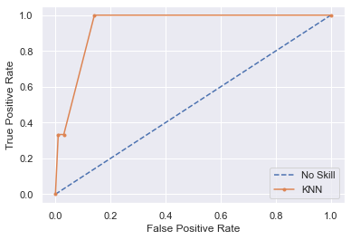

```python
ns_probs = [0 for i in range(len(y_test))]
lr_probs = KNN_classifier.predict_proba(X_test)[:,1]
# calculating scores for no skill and KNN
ns_auc = roc_auc_score(y_test, ns_probs)
lr_auc = roc_auc_score(y_test, lr_probs)
print('No Skill: ROC AUC=%.3f' % (ns_auc))
print('KNN: ROC AUC=%.3f' % (lr_auc))

# calculate roc curves
ns_fpr, ns_tpr, _ = roc_curve(y_test, ns_probs)
lr_fpr, lr_tpr, _ = roc_curve(y_test, lr_probs)
# plot the roc curve for the model
plt.plot(ns_fpr, ns_tpr, linestyle='--', label='No Skill')
plt.plot(lr_fpr, lr_tpr, marker='.', label='KNN')
# axis labels
plt.xlabel('False Positive Rate')
plt.ylabel('True Positive Rate')
# show the legend
plt.legend()
# show the plot
plt.show()
```

```python
from sklearn.model_selection import cross_val_score
import sklearn.metrics
sorted(sklearn.metrics.SCORERS.keys())
```

```
['accuracy',
 'adjusted_mutual_info_score',
 'adjusted_rand_score',
 'average_precision',
 'balanced_accuracy',
 'completeness_score',
 'explained_variance',
 'f1',
 'f1_macro',
 'f1_micro',
 'f1_samples',
 'f1_weighted',
 'fowlkes_mallows_score',
 'homogeneity_score',
 'jaccard',
 'jaccard_macro',
 'jaccard_micro',
 'jaccard_samples',
 'jaccard_weighted',
 'max_error',
 'mutual_info_score',
 'neg_brier_score',
 'neg_log_loss',
 'neg_mean_absolute_error',
 'neg_mean_gamma_deviance',
 'neg_mean_poisson_deviance',
 'neg_mean_squared_error',
 'neg_mean_squared_log_error',
 'neg_median_absolute_error',
 'neg_root_mean_squared_error',
 'normalized_mutual_info_score',
 'precision',
 'precision_macro',
 'precision_micro',
 'precision_samples',
 'precision_weighted',
 'r2',
 'recall',
 'recall_macro',
 'recall_micro',
 'recall_samples',
 'recall_weighted',
 'roc_auc',
 'roc_auc_ovo',
 'roc_auc_ovo_weighted',
 'roc_auc_ovr',
 'roc_auc_ovr_weighted',
 'v_measure_score']
```

```python
accuracy = cross_val_score(estimator = KNN_classifier, X = X_train, y = y_train, cv = 5 , scoring="accuracy" )
```

```python
1-accuracy
```

```
array([0.07407407, 0.09876543, 0.09876543, 0.08641975, 0.1       ])
```

```python
error_rate=round((1-accuracy).mean(),4)
error_rate
```

```
0.0916
```

```python
error_rate = []
k=50

for i in range(1,k):
    KNN_i = KNeighborsClassifier(n_neighbors=i)
    KNN_i.fit(X_train, y_train)
    error_rate.append(np.mean(y_test != KNN_i.predict(X_test)) )
```

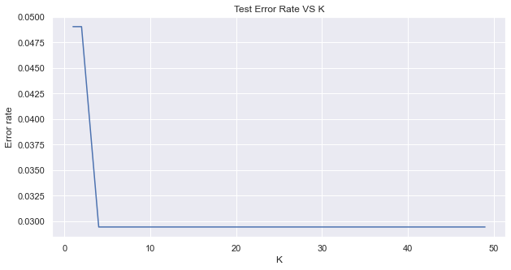

```python
plt.figure(figsize=(10,5))
sns.lineplot(y=error_rate, x=range(1,k))
plt.title('Test Error Rate VS K')
plt.xlabel('K')
plt.ylabel('Error rate')
plt.show()
```

```python
error_rate_test = []
error_rate_CV=[]
k=50

for i in range(1,k):
    KNN_i = KNeighborsClassifier(n_neighbors=i)
    KNN_i.fit(X_train, y_train)
    accuracy =  cross_val_score(estimator = KNN_i, X = X_train, y = y_train, cv = 5 , scoring="accuracy")
    error_rate_CV.append(np.mean(1-accuracy))
    error_rate_test.append(np.mean(y_test != KNN_i.predict(X_test)) )

optimal_k = pd.DataFrame({'error_rate_CV': error_rate_CV, 'error_rate_test':error_rate_test}, index=range(1,k))
```

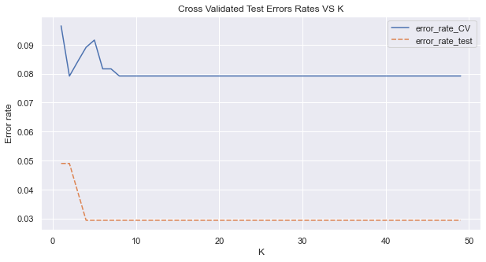

```python
plt.figure(figsize=(10,5))
sns.lineplot(data=optimal_k)
plt.title('Cross Validated Test Errors Rates VS K')
plt.xlabel('K')
plt.ylabel('Error rate')
plt.show()
```

```python
my_KNN_report(X_train, y_train, X_test,y_test, K=4, threshold=0.7)
```

```
-----------------------------------------
Accuracy  = 0.9706
Error_rate  = 0.0294
Precision = 0.5
Recall    = 0.33
f1_score  = 0.4
-----------------------------------------
```

|  | Predict : negative | Predict :positive |
| --- | --- | --- |
| Actual : negative | 98 | 1 |
| Actual : positive | 2 | 1 |

## SVM Classification

```python
df = pd.read_csv("boston_clean.csv")
```

```python
scale = StandardScaler()
df_sc = scale.fit_transform(df)
df_sc = pd.DataFrame(df_sc, columns=df.columns)
df_sc['CHAS']=df['CHAS']
```

```python
df_sc.head()
```

|  | CRIM | ZN | INDUS | CHAS | NOX | RM | AGE | DIS | RAD | TAX | PTRATIO | B | LSTAT | price |
| --- | --- | --- | --- | --- | --- | --- | --- | --- | --- | --- | --- | --- | --- | --- |
| 0 | -0.419782 | 0.284830 | -1.287909 | 0.0 | -0.144217 | 0.413672 | -0.120013 | 0.140214 | -0.982843 | -0.666608 | -1.459000 | 0.441052 | -1.075562 | 0.159686 |
| 1 | -0.417339 | -0.487722 | -0.593381 | 0.0 | -0.740262 | 0.194274 | 0.367166 | 0.557160 | -0.867883 | -0.987329 | -0.303094 | 0.441052 | -0.492439 | -0.101524 |
| 2 | -0.417342 | -0.487722 | -0.593381 | 0.0 | -0.740262 | 1.282714 | -0.265812 | 0.557160 | -0.867883 | -0.987329 | -0.303094 | 0.396427 | -1.208727 | 1.324247 |
| 3 | -0.416750 | -0.487722 | -1.306878 | 0.0 | -0.835284 | 1.016303 | -0.809889 | 1.077737 | -0.752922 | -1.106115 | 0.113032 | 0.416163 | -1.361517 | 1.182758 |
| 4 | -0.412482 | -0.487722 | -1.306878 | 0.0 | -0.835284 | 1.228577 | -0.511180 | 1.077737 | -0.752922 | -1.106115 | 0.113032 | 0.441052 | -1.026501 | 1.487503 |

```python
y = df_sc['CHAS']
X = df_sc.drop('CHAS', axis=1) # becareful inplace= False

from sklearn.model_selection import train_test_split
X_train, X_test, y_train, y_test = train_test_split(X, y, test_size=0.3, random_state=rand_state)
```

```python
from sklearn.svm import SVC
```

```python
# Fitting SVM regression to the Training set
SVM_classification = SVC()
SVM_classification.fit(X_train, y_train)
```

```
SVC()
```

```python
# Predicting the Test set results
y_hat = SVM_classification.predict(X_test)
```

```python
predictions = pd.DataFrame({ 'y_test':y_test,'y_hat':y_hat})
predictions.tail(20)
```

|  | y_test | y_hat |
| --- | --- | --- |
| 296 | 0.0 | 0.0 |
| 249 | 0.0 | 0.0 |
| 142 | 1.0 | 0.0 |
| 150 | 0.0 | 0.0 |
| 167 | 0.0 | 0.0 |
| 34 | 0.0 | 0.0 |
| 183 | 0.0 | 0.0 |
| 207 | 0.0 | 0.0 |
| 15 | 0.0 | 0.0 |
| 397 | 0.0 | 0.0 |
| 220 | 1.0 | 0.0 |
| 473 | 0.0 | 0.0 |
| 404 | 0.0 | 0.0 |
| 63 | 0.0 | 0.0 |
| 218 | 1.0 | 0.0 |
| 177 | 0.0 | 0.0 |
| 82 | 0.0 | 0.0 |
| 341 | 0.0 | 0.0 |
| 377 | 0.0 | 0.0 |
| 479 | 0.0 | 0.0 |

```python
from sklearn.metrics import confusion_matrix
from sklearn.metrics import accuracy_score, recall_score, precision_score, f1_score



def my_SVM_report(X_train, y_train, X_test,y_test, C=1,gamma='scale' ,kernel='rbf'):
    svc= SVC(C=C, gamma=gamma, kernel=kernel)
    svc.fit(X_train, y_train)
    y_hat = svc.predict(X_test)

    cm = confusion_matrix(y_test, y_hat)
    accuracy = round(accuracy_score(y_test,y_hat) ,4)
    error_rate = round(1-accuracy,4)
    precision = round(precision_score(y_test,y_hat),2)
    recall = round(recall_score(y_test,y_hat),2)
    f1score = round(f1_score(y_test,y_hat),2)
    cm_labled = pd.DataFrame(cm, index=['Actual : negative ','Actual : positive'], columns=['Predict : negative','Predict :positive '])

    print("-----------------------------------------")
    print('Accuracy  = {}'.format(accuracy))
    print('Error_rate  = {}'.format(error_rate))
    print('Precision = {}'.format(precision))
    print('Recall    = {}'.format(recall))
    print('f1_score  = {}'.format(f1score))
    print("-----------------------------------------")
    return cm_labled
```

```python
my_SVM_report(X_train, y_train, X_test,y_test, kernel='rbf')
```

```
-----------------------------------------
Accuracy  = 0.9408
Error_rate  = 0.0592
Precision = 0.0
Recall    = 0.0
f1_score  = 0.0
-----------------------------------------
```

|  | Predict : negative | Predict :positive |
| --- | --- | --- |
| Actual : negative | 143 | 0 |
| Actual : positive | 9 | 0 |

Tuning hyperparamiters

```python
my_param_grid = {'C': [10,100,1000], 'gamma': ['scale',0.01,0.001], 'kernel': ['rbf']}
```

```python
from sklearn.model_selection import GridSearchCV
```

```python
GridSearchCV(estimator=SVC(),param_grid= my_param_grid, refit = True, verbose=2, cv=5 )
```

```
GridSearchCV(cv=5, estimator=SVC(),
             param_grid={'C': [10, 100, 1000], 'gamma': ['scale', 0.01, 0.001],
                         'kernel': ['rbf']},
             verbose=2)
```

```python
grid = GridSearchCV(estimator=SVC(),param_grid= my_param_grid, refit = True, verbose=2, cv=5 )
```

```python
grid.fit(X_train,y_train)
```

[output not shown]

```
[Parallel(n_jobs=1)]: Using backend SequentialBackend with 1 concurrent workers.
[Parallel(n_jobs=1)]: Done   1 out of   1 | elapsed:    0.0s remaining:    0.0s
```

[output not shown]

```
[Parallel(n_jobs=1)]: Done  45 out of  45 | elapsed:    0.5s finished
```

```
GridSearchCV(cv=5, estimator=SVC(),
             param_grid={'C': [10, 100, 1000], 'gamma': ['scale', 0.01, 0.001],
                         'kernel': ['rbf']},
             verbose=2)
```

```python
grid.best_params_
```

```
{'C': 10, 'gamma': 'scale', 'kernel': 'rbf'}
```

```python
grid.best_estimator_
```

```
SVC(C=10)
```

```python
y_hat_optimized = grid.predict(X_test)
```

```python
predictions['y_hat_optimized'] = y_hat_optimized
predictions.tail(20)
```

|  | y_test | y_hat | y_hat_optimized |
| --- | --- | --- | --- |
| 296 | 0.0 | 0.0 | 0.0 |
| 249 | 0.0 | 0.0 | 0.0 |
| 142 | 1.0 | 0.0 | 0.0 |
| 150 | 0.0 | 0.0 | 0.0 |
| 167 | 0.0 | 0.0 | 0.0 |
| 34 | 0.0 | 0.0 | 0.0 |
| 183 | 0.0 | 0.0 | 0.0 |
| 207 | 0.0 | 0.0 | 0.0 |
| 15 | 0.0 | 0.0 | 0.0 |
| 397 | 0.0 | 0.0 | 0.0 |
| 220 | 1.0 | 0.0 | 0.0 |
| 473 | 0.0 | 0.0 | 0.0 |
| 404 | 0.0 | 0.0 | 0.0 |
| 63 | 0.0 | 0.0 | 0.0 |
| 218 | 1.0 | 0.0 | 1.0 |
| 177 | 0.0 | 0.0 | 0.0 |
| 82 | 0.0 | 0.0 | 0.0 |
| 341 | 0.0 | 0.0 | 0.0 |
| 377 | 0.0 | 0.0 | 0.0 |
| 479 | 0.0 | 0.0 | 0.0 |

```python
my_SVM_report(X_train, y_train, X_test,y_test,C=10, gamma='scale')
```

```
-----------------------------------------
Accuracy  = 0.9474
Error_rate  = 0.0526
Precision = 0.67
Recall    = 0.22
f1_score  = 0.33
-----------------------------------------
```

|  | Predict : negative | Predict :positive |
| --- | --- | --- |
| Actual : negative | 142 | 1 |
| Actual : positive | 7 | 2 |

```python
from sklearn.model_selection import cross_val_score
```

```python
f1_score = cross_val_score(estimator = SVC(C=10, gamma='scale'), X = X_train, y = y_train, cv = 5 , scoring="f1" )
```

```python
f1_score
```

```
array([0.        , 0.28571429, 0.        , 0.5       , 0.33333333])
```

```python
f1_CV=round(f1_score.mean(),4)
f1_CV
```

```
0.2238
```

## Decision Trees Classification

```python
df = pd.read_csv("boston_clean.csv")
```

```python
y = df['CHAS']
X = df.drop('CHAS', axis=1) # becareful inplace= False

from sklearn.model_selection import train_test_split
X_train, X_test, y_train, y_test = train_test_split(X, y, test_size=0.3, random_state=rand_state)
```

```python
from sklearn.tree import DecisionTreeClassifier
```

```python
Tree_classifier = DecisionTreeClassifier()
Tree_classifier.fit(X_train, y_train)
```

```
DecisionTreeClassifier()
```

```python
y_hat = Tree_classifier.predict(X_test)
```

```python
from sklearn.metrics import accuracy_score, recall_score, precision_score, f1_score
from sklearn.metrics import confusion_matrix, classification_report, roc_curve, roc_auc_score
```

```python
print(confusion_matrix(y_test, y_hat))
```

```
[[137   6]
 [  8   1]]
```

```python
print(classification_report(y_test, y_hat))
```

```
              precision    recall  f1-score   support

         0.0       0.94      0.96      0.95       143
         1.0       0.14      0.11      0.12         9

    accuracy                           0.91       152
   macro avg       0.54      0.53      0.54       152
weighted avg       0.90      0.91      0.90       152
```

Accuracy is great at 91%, but we know the target variable is inbalanced so we want to focus on the F1 score which is sitting at a dismal .12. Let's see if we can optimize the model for better results.

```python
path = DecisionTreeClassifier().cost_complexity_pruning_path(X_train,y_train)
```

```python
path
```

```
{'ccp_alphas': array([0.        , 0.00256805, 0.00311989, 0.00376648, 0.00410889,
        0.00451977, 0.0047081 , 0.00484262, 0.00642013, 0.00647167,
        0.00908459, 0.0102362 ]),
 'impurities': array([0.        , 0.00513611, 0.02697535, 0.03827479, 0.04238367,
        0.04690345, 0.05161154, 0.06129677, 0.06771691, 0.10654694,
        0.11563153, 0.13610393])}
```

```python
ccp_alphas = path.ccp_alphas
```

```python
from sklearn.model_selection import cross_val_score
import sklearn.metrics
```

```python
accuracy_cv =[]
for alpha in ccp_alphas:
    accuracy = cross_val_score(estimator = DecisionTreeClassifier(ccp_alpha=alpha), X = X_train, y = y_train, cv = 5 , scoring="accuracy" )
    accuracy_cv.append(np.mean(accuracy))

output = pd.DataFrame(list(ccp_alphas), columns=['alpha'])
output['accuracy_CV']=accuracy_cv

output.head()
```

|  | alpha | accuracy_CV |
| --- | --- | --- |
| 0 | 0.000000 | 0.875775 |
| 1 | 0.002568 | 0.867364 |
| 2 | 0.003120 | 0.878632 |
| 3 | 0.003766 | 0.884225 |
| 4 | 0.004109 | 0.881408 |

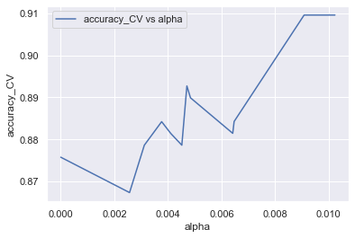

```python
sns.lineplot(x='alpha', y='accuracy_CV', data=output , color='b', label="accuracy_CV vs alpha")
plt.show()
```

```python
np.argmax(output['accuracy_CV'])
```

```
10
```

```python
output.iloc[np.argmax(output['accuracy_CV']),]
```

```
alpha          0.009085
accuracy_CV    0.909577
Name: 10, dtype: float64
```

```python
optimal_alpha = output.iloc[np.argmax(output['accuracy_CV']),0]
optimal_alpha
```

```
0.00908459246021405
```

```python
optimal_DT = DecisionTreeClassifier(ccp_alpha=optimal_alpha)
optimal_DT.fit(X_train, y_train)
y_hat_optimized = optimal_DT.predict(X_test)
```

```python
print(confusion_matrix(y_test, y_hat_optimized))
```

```
[[142   1]
 [  9   0]]
```

```python
print(classification_report(y_test, y_hat_optimized))
```

```
              precision    recall  f1-score   support

         0.0       0.94      0.99      0.97       143
         1.0       0.00      0.00      0.00         9

    accuracy                           0.93       152
   macro avg       0.47      0.50      0.48       152
weighted avg       0.88      0.93      0.91       152
```

## Random Forest Classification

```python
y = df['CHAS']
X = df.drop(['CHAS'], axis=1) # becareful inplace= False

from sklearn.model_selection import train_test_split
X_train, X_test, y_train, y_test = train_test_split(X, y, test_size=0.3, random_state=rand_state)
```

```python
from sklearn.ensemble import RandomForestClassifier
```

```python
# Fitting RF classifier to the Training set

RF_classifier = RandomForestClassifier(random_state=rand_state)
RF_classifier.fit(X_train, y_train)
```

```
RandomForestClassifier(random_state=1000)
```

```python
# Predicting the Test set probabilities and classes
y_hat = RF_classifier.predict(X_test)
y_hat_probs = RF_classifier.predict_proba(X_test)[:,1]
# predicted probabilities are reported for both classes. we saved the prob of purchased!
```

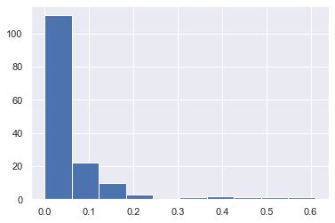

```python
plt.hist(y_hat_probs)
plt.show()
```

```python
from sklearn.metrics import accuracy_score, recall_score, precision_score, f1_score
from sklearn.metrics import confusion_matrix, classification_report, roc_curve, roc_auc_score
```

#### Confusion matrix

```python
print(confusion_matrix(y_test, y_hat))
```

```
[[141   2]
 [  9   0]]
```

#### Built-in classification report

```python
print(classification_report(y_test, y_hat))
```

```
              precision    recall  f1-score   support

         0.0       0.94      0.99      0.96       143
         1.0       0.00      0.00      0.00         9

    accuracy                           0.93       152
   macro avg       0.47      0.49      0.48       152
weighted avg       0.88      0.93      0.91       152
```

As expected, accuracy is great but our metric of interest, F1, is at 0. Let's try the balanced_subsample feature and see if that helps.

```python
RF_balanced = RandomForestClassifier(random_state=rand_state, criterion='entropy', max_features='log2', max_depth=None, class_weight='balanced_subsample')
```

```python
y_hat_balanced = RF_balanced.fit(X_train, y_train).predict(X_test)
```

```python
print(confusion_matrix(y_test, y_hat_balanced))
```

```
[[141   2]
 [  9   0]]
```

```python
print(classification_report(y_test, y_hat_balanced))
```

```
              precision    recall  f1-score   support

         0.0       0.94      0.99      0.96       143
         1.0       0.00      0.00      0.00         9

    accuracy                           0.93       152
   macro avg       0.47      0.49      0.48       152
weighted avg       0.88      0.93      0.91       152
```

Still no luck. It seems that RF is not the model for this data/question.

## Boosting Classification

```python
from sklearn.ensemble import AdaBoostClassifier, GradientBoostingClassifier
```

```python
from xgboost import XGBClassifier
```

```python
y = df['CHAS']
X = df.drop(['CHAS'], axis=1) # becareful inplace= False

from sklearn.model_selection import train_test_split
X_train, X_test, y_train, y_test = train_test_split(X, y, test_size=0.3, random_state=rand_state)
```

```python
%%time
# Fitting AdaBoost classifier to the Training set
AdB_classifier = AdaBoostClassifier(random_state=rand_state)
AdB_classifier.fit(X_train, y_train)
```

```
Wall time: 141 ms
```

```
AdaBoostClassifier(random_state=1000)
```

```python
%%time
# Fitting Gradient Boosting classifier to the Training set
GBM_classifier = GradientBoostingClassifier(random_state=rand_state)
GBM_classifier.fit(X_train, y_train)
```

```
Wall time: 276 ms
```

```
GradientBoostingClassifier(random_state=1000)
```

```python
%%time
# Fitting XGBoost classifier to the Training set
XGB_classifier = XGBClassifier(random_state=rand_state)
XGB_classifier.fit(X_train, y_train)
```

```
[10:34:07] WARNING: C:/Users/Administrator/workspace/xgboost-win64_release_1.4.0/src/learner.cc:1095: Starting in XGBoost 1.3.0, the default evaluation metric used with the objective 'binary:logistic' was changed from 'error' to 'logloss'. Explicitly set eval_metric if you'd like to restore the old …
Wall time: 115 ms
```

```
XGBClassifier(base_score=0.5, booster='gbtree', colsample_bylevel=1,
              colsample_bynode=1, colsample_bytree=1, gamma=0, gpu_id=-1,
              importance_type='gain', interaction_constraints='',
              learning_rate=0.300000012, max_delta_step=0, max_depth=6,
              min_child_weight=1, missing=nan, monotone_constraints='()',
              n_estimators=100, n_jobs=4, num_parallel_tree=1,
              random_state=1000, reg_alpha=0, reg_lambda=1, scale_pos_weight=1,
              subsample=1, tree_method='exact', validate_parameters=1,
              verbosity=None)
```

```python
# Predicting the Test set probabilities and classes
y_hat_AdB      = AdB_classifier.predict(X_test)
y_hat_GBM      = GBM_classifier.predict(X_test)
y_hat_XGB      = XGB_classifier.predict(X_test)
```

```python
from sklearn.metrics import accuracy_score, recall_score, precision_score, f1_score
from sklearn.metrics import confusion_matrix, classification_report, roc_curve, roc_auc_score
```

```python
print('AdB f1 = {}'.format(f1_score(y_test, y_hat_AdB)))
print('GBM f1 = {}'.format(f1_score(y_test, y_hat_GBM)))
print('XGB f1 = {}'.format(f1_score(y_test, y_hat_XGB)))
```

```
AdB f1 = 0.0
GBM f1 = 0.16666666666666666
XGB f1 = 0.1818181818181818
```

Just like with the regression problem, XGB is performing best out of the 3 models.

# **Classification Summary**

```python
table = [["KNN", 0.40], ["SVM", 0.22], ["XGBoost", 0.18], ["GBM", 0.17], ["Logistic Regression", 0.14], ["Decision Trees", 0.12], ["AdaBoost", 0.00], ["Random Forest", 0.00]]
```

```python
print(tabulate(table, headers=["","F1 Score"], tablefmt='fancy_grid'))
```

```
╒═════════════════════╤════════════╕
│                     │   F1 Score │
╞═════════════════════╪════════════╡
│ KNN                 │       0.4  │
├─────────────────────┼────────────┤
│ SVM                 │       0.22 │
├─────────────────────┼────────────┤
│ XGBoost             │       0.18 │
├─────────────────────┼────────────┤
│ GBM                 │       0.17 │
├─────────────────────┼────────────┤
│ Logistic Regression │       0.14 │
├─────────────────────┼────────────┤
│ Decision Trees      │       0.12 │
├─────────────────────┼────────────┤
│ AdaBoost            │       0    │
├─────────────────────┼────────────┤
│ Random Forest       │       0    │
╘═════════════════════╧════════════╛
```

# **Conclusion**

```python
print(tabulate(regression_table, headers=["","RMSE"], tablefmt='fancy_grid'))
```

```
╒════════════════╤════════╕
│                │   RMSE │
╞════════════════╪════════╡
│ SVM            │   0.39 │
├────────────────┼────────┤
│ Polynomial     │   0.42 │
├────────────────┼────────┤
│ KNN            │   0.47 │
├────────────────┼────────┤
│ Lasso          │   0.55 │
├────────────────┼────────┤
│ Elastic Net    │   0.55 │
├────────────────┼────────┤
│ Ridge          │   0.55 │
├────────────────┼────────┤
│ Linear         │   0.56 │
├────────────────┼────────┤
│ XGBoost        │   4.06 │
├────────────────┼────────┤
│ Random Forest  │   4.09 │
├────────────────┼────────┤
│ GBM            │   4.18 │
├────────────────┼────────┤
│ Decision Trees │   4.72 │
├────────────────┼────────┤
│ AdaBoost       │   4.93 │
╘════════════════╧════════╛
```

For the classification problem, KNN has the best F1 score and thus that model is best for predicting whether or not a tract is bordering the Charles River.